# Exploratory Data Analysis for 5 Football Leagues

Exploratory data analysis for English, German, Spanish, Italian and French results combined.

## Summary of All Variables

```r
summary(all_features %>% select(HS, HST, HC, HF, HY, HomexG, Dist, winpc_H, top6_perfH))
```

```
       HS             HST               HC               HF              HY           HomexG           Dist
 Min.   : 0.00   Min.   : 0.000   Min.   : 0.000   Min.   : 0.00   Min.   :0.00   Min.   :0.000   Min.   :   0.0
 1st Qu.:10.00   1st Qu.: 3.000   1st Qu.: 4.000   1st Qu.:11.00   1st Qu.:1.00   1st Qu.:0.850   1st Qu.: 175.1
 Median :13.00   Median : 5.000   Median : 5.000   Median :14.00   Median :2.00   Median :1.370   Median : 304.3
 Mean   :13.82   Mean   : 5.399   Mean   : 5.803   Mean   :14.25   Mean   :1.82   Mean   :1.511   Mean   : 360.0
 3rd Qu.:17.00   3rd Qu.: 7.000   3rd Qu.: 8.000   3rd Qu.:17.00   3rd Qu.:3.00   3rd Qu.:2.040   3rd Qu.: 494.2
 Max.   :44.00   Max.   :24.000   Max.   :22.000   Max.   :48.00   Max.   :8.00   Max.   :6.630   Max.   :2262.2
 NA's   :272     NA's   :1040     NA's   :597      NA's   :929     NA's   :258    NA's   :23928
    winpc_H         top6_perfH
 Min.   :  0.00   Min.   :0.0000
 1st Qu.: 25.00   1st Qu.:0.1667
 Median : 33.33   Median :0.3333
 Mean   : 36.66   Mean   :0.3322
 3rd Qu.: 46.67   3rd Qu.:0.4667
 Max.   :100.00   Max.   :1.0000
                  NA's   :197
```

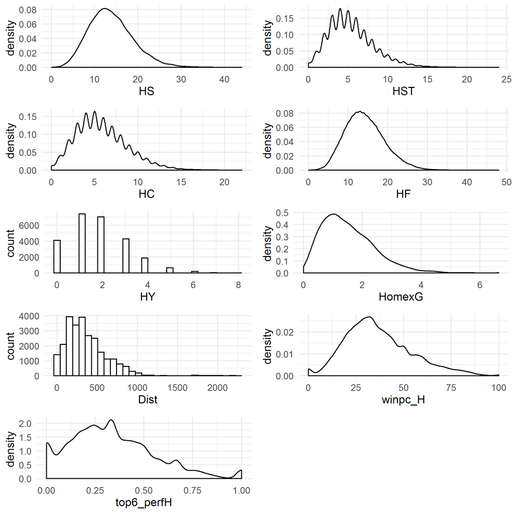

No feature transformations are deemed to be necessary.

## Creation of Additional Features

To reflect the under- or over-preformance of a team, compared with the quality of chances created, new features are derived. These are **Taken Chance = Goals Scored / xG** and **Defended Chance = Opposition xG / Goals Conceded**.

- LastHTC means Last Home Taken Chance
- LastHDC means Last Home Defended Chance

To remove zeros, an offset of +1 is applied to both Goals Scored and xG values.

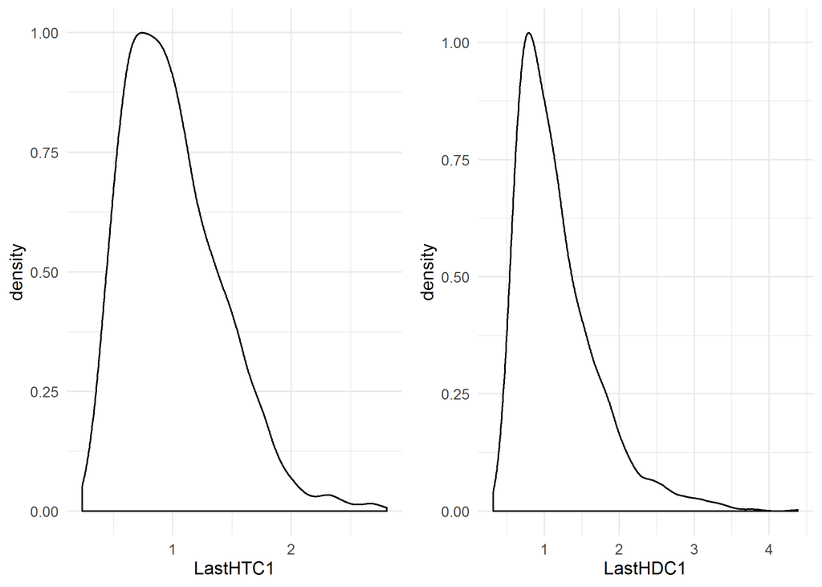

These features will be log transformed.

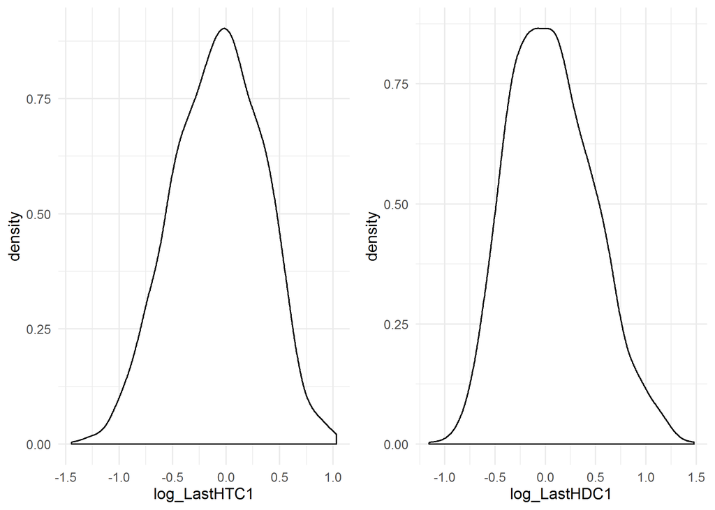

## Feature Correlations

A plot to demonstrate how much correlation is observed between feature variables. Just comparing Home variables for last game.

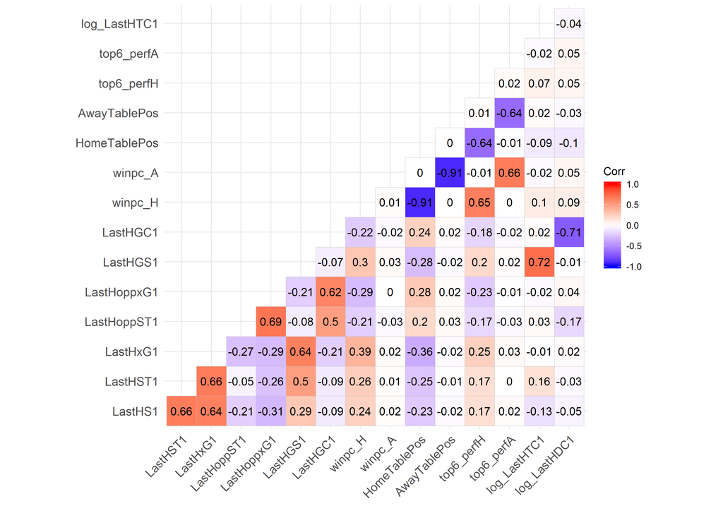

This plot shows that:

- win percentage is highly inversely correlated to table position -> just keep win percentage
- goals scored correlated with taken chances, however does give additional information so will keep both for now
- goals conceded inversely correlated with defended chances, however gives additional information so will keep both for now
- shots, shots on target and xG, both for and against somewhat correlated with each other -> have a lot of shots data and not much xG data, so perhaps just keep both shots and shots on target for now

## Focus on High Odds Aways

Looking for predictive value, we are trying to predict Away wins where odds are somewhat high. We will filter the data to only investigate games where Away odds > 3.

```
overall:
    0     1
13171  2917

by season:
```

| season | AwayWin_0 | AwayWin_1 | prop_Away |
| --- | --- | --- | --- |
| 0 | 810 | 166 | 0.1700820 |
| 1 | 817 | 194 | 0.1918892 |
| 2 | 823 | 185 | 0.1835317 |
| 3 | 797 | 192 | 0.1941355 |
| 4 | 817 | 156 | 0.1603289 |
| 5 | 847 | 192 | 0.1847931 |
| 6 | 824 | 170 | 0.1710262 |
| 7 | 837 | 178 | 0.1753695 |
| 8 | 809 | 198 | 0.1966236 |
| 9 | 803 | 180 | 0.1831129 |

[output cut: 10 more lines]

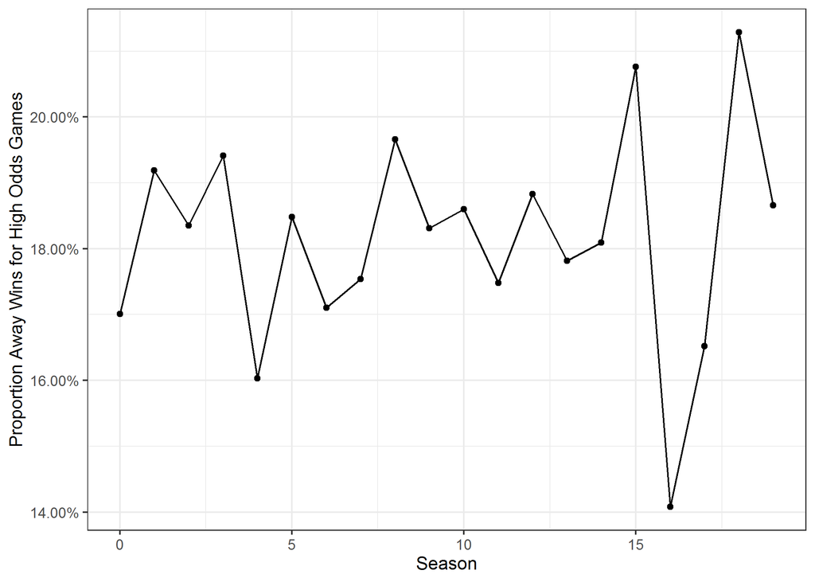

Therefore, approximately 18% of these games are Away wins. We have 62% of games that have high Away odds. The proprtion of these that are Away wins varies from ~14-21% by season and trend may be increasing.

## Two Variable Plots

Plots to illustrate how each variable individually affects the outcome.

[figure not shown]

Conclusions on relationship with Away Win proportion that we can draw from these:

- Clear relationships with Home win percentage and Home performance against top 6, but much weaker for Away
- Last Home Finish highly correlated up to bottom of table finish then reverses at about 18th; Away Finish relationship weaker
- Last Home shots on target, corners, goals scored, fouls, goals conceded, have some relationship
- Last Away shots on target has some relationship
- Distance relationship is unclear
- Some variability with Month - higher proportion for Sep, Nov and Mar

So we’ll take the following forward:

- winpc_H, winpc_A
- top6_perfH, top6_perfA
- HomeFin, AwayFin
- Month
- LastHST1-4, LastHC1-4, LastHGS1-4, LastHF1-4 and LastHGC1-4
- LastAST1-4

However, how do summed variables compare?

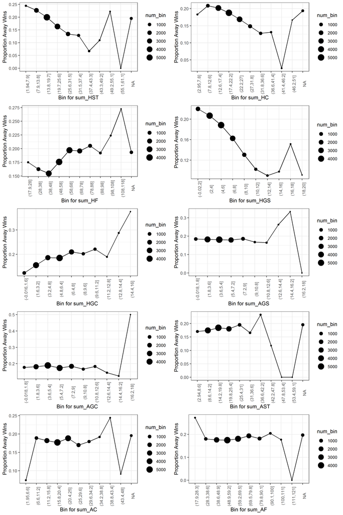

This additional data suggests:

- sum_HST, sum_HC, sum_HF, sum_HGS, sum_HGC are useful
- sum_AST may be useful
- others are marginal or not useful

Perhaps the summed variables will actually perform better.